# Praca domowa 2

Paweł Morgen

07/11/2019

## Przedstawienie wersji funkcji

Funkcje tworzące nazywałem `NSE_factory_n(FUNCTION)`, gdzie n - numer wersji (od 1 do 3).

### 0. Funkcje pomocnicze

Domyślnie te funkcje powinny się znaleźć wewnątrz ciał funkcji `NSE_function_n`, ale dla większej przejrzystości zamieszczam je tutaj.

```r
get_argument_name <- function(original){
  # Funkcja zwraca nazwę nowego argumentu, która nie kłóci się z nazwami argumentów funkcji original.
  # Domyślnie: "env".
  # Występuje we wszystkich wersjach.
  env_name <- "env"
  while(env_name %in% names(get_formals(original)))
    env_name <- paste0(env_name, "1")
  env_name
}

fix_argument_name <- function(new_name, FUNCTION){
  # Funkcja zastępuje nazwę pierwszego argumentu funkcji FUNCTION (env) nazwą new_name.
  # Zakładamy, że w ciele funkcji jedyne użycia env odwołują się do jej pierwszego argumentu.
  # Występuje w wersji 1 i 2.
  new_body <- capture.output(body(FUNCTION)) %>%
    stri_replace_all_fixed("env", new_name) %>%
    str2expression()
  body(FUNCTION) <- new_body[[1]]
  names(fn_fmls(FUNCTION))[1] <- new_name
  FUNCTION
}

concat_quotes <- function(...){
  # Funkcja przyjmuje obiekty typu expression i je konkatenuje w jeden obiekt typu expression otoczony {}.
  quotes <- list(...) %>%
    lapply(function(q) capture.output(q))
  str2expression(c("{",do.call(c, quotes), "}"))[[1]]
}


get_formals <- function(FUNCTION){
  # Funkcja przyjmuje na wejściu dowolną funkcję i zwraca listę jej argumentów.
  # Występuje w wersji 2 i 3.
  if(!is_primitive(FUNCTION)) return(fn_fmls(FUNCTION))
  # Zaczynamy zabawę.
  # Łapiemy to, co wypisuje wywołanie FUNCTION i robimy z tego jeden ogromny string.
  fn_string <- do.call(paste, as.list(capture.output(FUNCTION)))

  # Musimy znaleźć segment (arg1, arg2, arg3=function1(), ...).
  # Niestety, w środku mogą się pojawić wredne argumenty, których wartościami domyślnymi
  # są wartości zwracane przez wywołanie jakiejś funkcji - przez to nie możemy po prostu
  # poszukać zamykającego nawiasu. Robienie tego regexami byłoby zbyt trudne (konieczność rekurencji),
  # więc zastosowałem inny sposób.

  open_brackets <- stri_locate_all(fn_string, fixed = "(")[[1]][,1]
  closed_brackets <- stri_locate_all(fn_string, fixed = ")")[[1]][,1]
  names(open_brackets) <- rep("open", length(open_brackets))
  names(closed_brackets) <- rep("closed", length(closed_brackets))
  sorted_brackets <- c(open_brackets, closed_brackets) %>% sort()
  # sorted_brackets jest nazwanym wektorem liczb, które określają pozycję nawiasów w stringu fn_string.
  # jeśli name to "open" - chodzi o nawias "("; "closed" - ")".
  assign_weights <- function(str) {
    str[str=="open"]<-1
    str[str=="closed"]<- -1
    as.numeric(str)
  }
  summed_brackets <- assign_weights(names(sorted_brackets)) %>% cumsum()
  # Szukamy w summed_brackets 0. Indeks, na którym będzie, to będzie indeks obiektu sorted_brackets,
  # na którym stoi pozycja szukanego przez nas nawiasu zamykającego.
  # Stworzymy z summed_brackets stringa, który będzie ciągiem cyfr.
  # Nie interesują nas dokładne wartości liczb powyżej 10 - możemy je zamienić na 9.
  summed_brackets[summed_brackets >= 10] <- 9
  # Dzięki temu i-ty znak w stringu będzie odpowiadał i-tej liczbie z summed_brackets.
  brackets_as_int <- do.call(paste0, as.list(summed_brackets)) %>%
    stri_extract_first_regex(pattern = "1[1-9]*0")
  # brackets_as_int obcina informacje o wszystkich nawiasach do tych tworzących listę argumentów funkcji
  # lub wewnątrz tej listy.
  # inner_brackets - znajduje wszystkie pozycje startu i końca nawiasów związanych z wywołaniami
  # innych funkcji wewnątrz listy argumentów.
  inner_brackets <- stri_locate_all_regex(brackets_as_int,
                                          pattern = "2[2-9]*1",
                                          omit_no_match = TRUE)[[1]]
  # substring indexes przechowuje informację o pozycjach, na których zaczyna się i kończy lista argumentów.
  substring_indexes <- sorted_brackets[c(1, stri_length(brackets_as_int))]

  # Chcemy znaleźć same argumenty. Najłatwiej by było porozdzielać nasz string w miejscach,
  # gdzie są przecinki. Niestety, przecinki mogą się pojawić wewnątrz wywołań funkcji
  # wewnątrz listy argumentów.
  all_comas <- stri_locate_all_fixed(fn_string, ",", omit_no_match = TRUE)[[1]][,1]
  all_comas <- all_comas[all_comas < substring_indexes[2]]
  # inner_brackets - znajduje wszystkie pozycje startu i końca nawiasów związanych z wywołaniami
  # innych funkcji wewnątrz listy argumentów.
  inner_brackets <- stri_locate_all_regex(brackets_as_int,
                                          pattern = "2[2-9]*1",
                                          omit_no_match = TRUE)[[1]]
  # Jeśli wewnątrz listy argumentów nie ma wywołań innych funkcji, to każdy przecinek oddziela od siebie
  # argumenty. Jeśli są - pewne przecinki mogą występować wewnątrz wywołań innych funkcji:
   if(length(inner_brackets)!=0){
     forbidden_chars <- do.call(c, apply(inner_brackets, 1,
                      function(row) sorted_brackets[row[1]]:sorted_brackets[row[2]]))
     all_comas <- all_comas[!all_comas %in% forbidden_chars]
   }
  # może się zdarzyć, że nasza funkcja nie ma przecinków w liście argumentów.
  # Oznacza to, że ma tylko jeden argument.
   if(length(all_comas) != 0){
     begins <- as.list(c(substring_indexes[1], all_comas))
     # Ostatni string (odpowiadający ostatniemu argumentowi na liście) niech będzie bez ostatniego nawiasu.
     # Później go dołączymy
     ends <- as.list(c(all_comas-1, substring_indexes[2]-1))
     parted_arguments <- stri_sub_all(fn_string, begins, ends)
   }
   else parted_arguments <- list(stri_sub(fn_string, substring_indexes[1], substring_indexes[2]-1))

    # Oto powód całego zamieszania. Plan był taki, by sztucznie skonstruować wywołanie funkcji alist(),
    # ale ona w miejscach argumentów bez wartości domyślnej musi przyjąć input postaci "arg1=", nie "arg1".
    # Znajdźmy zatem argumenty bez wartości domyślnej (bez "=") i dołączmy do nich "=".
   parted_arguments[!stri_detect_fixed(parted_arguments, "=")] <- parted_arguments[!stri_detect_fixed(
      parted_arguments, "=")] %>%
     lapply(function(str) paste(str, "= "))
   # Dołączamy nawias i v'oila!
   parted_arguments <- append(parted_arguments, ")")
   formals_string <- do.call(paste0, parted_arguments)
   paste0("alist", formals_string) %>% parse_expr() %>% eval()
}
```

### 1. Wersja pierwsza

Pomysł jest prosty - zwracana funkcja przyjmuje 2 argumenty: `env` - listę, data.frame lub coś środowiskopodobnego (domyślnie: środowisko wzywającego funkcję `FUNCTION`) i elipsę.

Oczywiście, może się zdarzyć, że funkcja `FUNCTION` wśród swoich argumentów ma argument o nazwie `env`. Wówczas przy pomocy funkcji pomocniczych `get_argument_name()` i `fix_argument_name()` następuje poprawka. Dla ustalenia uwagi w dalszej części pracy zakładam, że pierwszy argument *rzeczywiście* nazywa się `env`.

```r
NSE_factory_1 <- function(FUNCTION){
  stopifnot(is_function(FUNCTION))
  out <- function(env = caller_env(), ...){
    given_args <- quos(...)
    evaluated_args <- lapply(given_args, function(expr) eval(quo_squash(expr), env))
    do.call(FUNCTION, evaluated_args)
  }
  correct_argument_name <- get_argument_name(FUNCTION)
  if(correct_argument_name != "env")
    out <- fix_argument_name(correct_argument_name, out)
  out
}
```

### 2. Wersja druga

Zaczęło się od marzenia: *A co, gdyby zwracana funkcja dziedziczyła argumenty funkcji FUNCTION?* .

Pomocna była funkcja `rlang::fn_fmls()`. Niestety, nie działa na funkcje prymitywne - tu musiałem radzić sobie po swojemu, co widać wyżej w ciele funkcji `get_formals()`.

Wersja druga funkcji zwraca funkcję, która na pierwszym miejscu ma argument `env` - jak w wersji pierwszej. Pozostałe argumenty są identyczne, jak funkcji FUNCTION.

```r
NSE_factory_2 <- function(FUNCTION){
  stopifnot(is_function(FUNCTION))
  arguments <- get_formals(FUNCTION)
  # Dołączamy do listy argumentów env z wartością domyślną "caller_env()".
  arguments <- append(arguments, call("caller_env"), 0)
  names(arguments)[[1]] <- "env"
  out <- function() {
    # Jest problem. Jako programista, nie wiem, jakie argumenty przyjmuje funkcja out.
    # Poszukamy ich w środowisku funkcji.
    arguments_names <- env_names(current_env())[-1]
    # Ignorujemy argumenty env i elipsę.
    for(name in arguments_names[arguments_names != "..."]){
      # Sytuacja wygląda tak: name <- arg1 <- val1. Jeśli np ktoś wywołał funkcję f(env, x = a),
      # to name jest referencją na x, x jest referencją na obiekt a,
      # który trzeba zewaluować w środowisku env.
      name <- parse_expr(name)
      new_name <- paste0("substitute(",
             deparse(expr_interp(name)), ")") %>% parse_expr()
      # W naszym przykładzie new_name <- substitute(x)
      if(eval(new_name) %>% is_missing()) next
      # eval(new_name) to niezewaluowany obiekt a
      new_value <- eval(eval(new_name) ,env)
      if(is.name(new_value)) next
      assign(x = deparse(name),value = new_value)
      # teraz w naszym środowisku mieszka nowa zmienna poprawnie zewaluowana. Dalej
    }
    # Teraz wszystkie zmienne są dobrze zewaluowane, poza ewentualną elipsą. Zbieramy je do kupy
    evaluated_arguments <- as.list(current_env())[arguments_names[arguments_names != "..."]]
    # Ewaluujemy elipsę sposobem z wersji pierwszej
    if("..." %in% arguments_names){
      arguments_extra <- quos(...)
      arguments_extra_evaluated <- lapply(arguments_extra,
             function(expr) eval(quo_squash(expr), env))
      # dołączamy do listy argumentów argumenty z elipsy, na dobre miejsce
      evaluated_arguments <- append(evaluated_arguments,
             arguments_extra_evaluated,
             which(arguments_names == "..."))
    }
    do.call(FUNCTION, evaluated_arguments)
  }
  formals(out) <- arguments
  correct_argument_name <- get_argument_name(FUNCTION)
  if(correct_argument_name != "env") out <- fix_argument_name(correct_argument_name, out)
  out
}
```

### 3. Wersja trzecia

Zwracana funkcja jest z zewnątrz identyczna, jak ta z wersji drugiej. Jednak jej ciało jest klarowniejsze. Zawdzięcza to temu, że jest konstruowane sztucznie, na zewnątrz deklaracji funkcji `out`.

```r
NSE_factory_3 <- function(FUNCTION){
  # Początek, jak w wersji 2
  stopifnot(is_function(FUNCTION))
  arguments <- get_formals(FUNCTION)
  arguments <- append(arguments, call("caller_env"), 0)
  new_argument_name <- get_argument_name(FUNCTION)
  names(arguments)[[1]] <- new_argument_name
  out <- function() {
    # tu się znajdzie:
    # if(!is_missing(arg1))
    #   arg1 <- eval(substitute(arg1), env)
    # if(!is_missing(arg2))
    # arg2 <- eval(substitute(arg2), env)
    # ...

    # Dlaczego przed ewaluacją każdego argumentu sprawdzam, czy go nie brakuje?
    # Niektóre funkcje (np lm) mają określone nietrywialne działanie na wypadek, gdy niektóre argumenty
    # na wejściu nie są podane. Celem na tym poziomie funkcji jest ewaluacja podanych przez użytkownika
    # argumentów w środowisku env.
    # Zajmowanie się przypadkiem braku argumentów zostawiamy funkcji oryginalnej.
    # Teoretycznie mógłbym nie sprawdzać braku argumentu dla argumentów z ustawioną wartością domyślną,
    # ale wredny użytkownik mógłby to obejść wywołaniem f(arg_z_wartością_domyślną = missing_argument()).

    # evaluated_arguments <- as.list(current_env())[c("arg1","arg2",...)]
    # Jeśli wśród argumentów jest elipsa:
    #   arguments_extra <- quos(...)
    #   lapply(arguments_extra,
    #          function(expr) eval(quo_squash(expr), env)) -> arguments_extra_evaluated
    #   append(evaluated_arguments,
    #          arguments_extra_evaluated,
    #          which(arguments_names == "...")) -> evaluated_arguments
    # }
    # do.call(FUNCTION, evaluated_arguments)
  }
  # Konstrrujemy obiekty typu expression, później je złączymy i ustawimy jako body(out).

  # Sekcja arg1 <- eval(substitute(arg1)):
  named_arguments <- names(arguments)[!names(arguments) %in% c(new_argument_name, "...")]
  quotes_list <- lapply(as.list(named_arguments),
         function(name) str2expression(
           paste0("if(!is_missing(substitute(", name, ")))",
                  name," <- eval(substitute(", name, "),",new_argument_name,")"))[[1]])

  # Linijka evaluated_arguments <- as.list(current_env())[c("arg1","arg2",...)]:
  arguments_list_assignment <- bquote(evaluated_arguments <- as.list(current_env())[.(named_arguments)])
  quotes_list <- append(quotes_list, arguments_list_assignment)

  # Sekcja z elipsą
  if("..." %in% names(arguments))
  quotes_list <- append(quotes_list,
         # Ewaluuj tylko części otoczone .() :
         bquote({
           arguments_extra <- quos(...)
           arguments_extra_evaluated <- lapply(arguments_extra,
                  function(expr) eval(quo_squash(expr), .(parse_expr(new_argument_name))))
           evaluated_arguments <- append(evaluated_arguments,
                  arguments_extra_evaluated,
                  .(which(names(arguments) == "...")))
         }))

  # Ostatnia linijka z do.call()
  quotes_list <- append(quotes_list, quote(do.call(FUNCTION, evaluated_arguments)))
  # V'oila:
  body(out) <- do.call(concat_quotes, quotes_list, quote = TRUE)
  formals(out) <- arguments
  out
}
```

## Testy

### Testy szybkości tworzenia funkcji

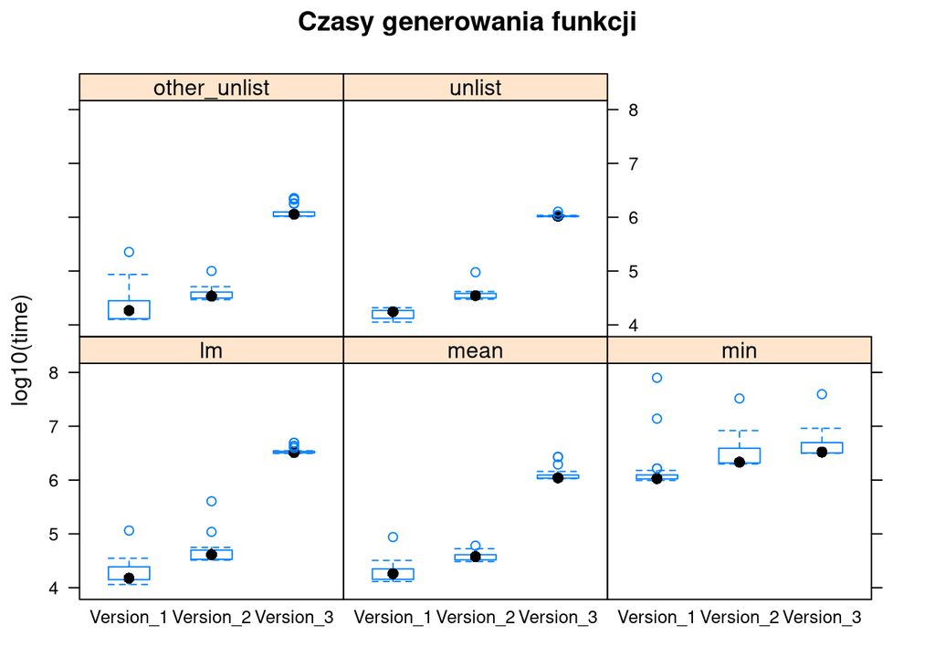

```r
other_unlist <- function(x, recursive = TRUE, use.names = TRUE) unlist(x, recursive, use.names)
results <- lapply(list(min, mean, lm, unlist, other_unlist), function(FUNCTION)
microbenchmark(Version_1 = NSE_factory_1(FUNCTION),
               Version_2 = NSE_factory_2(FUNCTION),
               Version_3 = NSE_factory_3(FUNCTION),
               times = 25))
results_df <- do.call(rbind, results) %>%
  mutate(Function = rep(c("min", "mean", "lm", "unlist", "other_unlist"),
                                    each = 75))
# ggplot(results_df, aes(x = expr, y = log10(time))) +
#   geom_boxplot() +
#   facet_wrap(~Function) +
#   labs(title = "Czasy generowania funkcji")
bwplot(log10(time) ~ expr | Function , results_df, main = "Czasy generowania funkcji")
```

Jak widzimy, wersja trzecia zostaje z tyłu za pozostałymi. Nic dziwnego - jej złożoność zależy od ilości argumentów (co widać przy `lm`) i od tego, czy funkcja na wejściu jest prymitywna.

### Zbiory do testów wynikowych funkcji

```r
# Tworzymy 3 zbiory: small, medium i big
set.seed(2019)
small <- lapply(1:20, function(x) 1) %>%
  append(list(rnorm(500, mean = runif(1, -10, 10),  sd = 20),
              rnorm(500, mean = runif(1, -10, 10),  sd = 20)), 0)
names(small) <- letters[1:22]
medium <- lapply(1:98, function(x) 1) %>%
  append(list(seq(-100, 100, 0.01)*rnorm(1, sd = 5)+runif(1, -10, 10),
              seq(-100, 100, 0.01)*rnorm(1, sd = 5)+runif(1, -10, 10)),0)
names(medium) <- stri_c(rep(letters[1:10], each = 10),
       rep(LETTERS[1:10], times = 10),
       collapse = ";") %>%
  stri_split(fixed = ";") %>% unlist()

big <- lapply(1:398, function(x) 1) %>%
  append(list(seq(-400, 400, 0.01)*rnorm(1, sd = 5)+runif(1, -10, 10),
              seq(-400, 400, 0.01)*rnorm(1, sd = 5)+runif(1, -10, 10)),0)
names(big) <- stri_c(rep(letters[1:20], each = 20),
                    rep(LETTERS[1:20], times = 20),
                    collapse = ";") %>%
  stri_split(fixed = ";") %>% unlist()

# Do unlist(use.names = TRUE) potrzebujemy kilku nazw. Poniżej są generowane kolejne wyrazy typu:
# AAAA, AAAB, AAAC, ..., ZZZZ
simple_names <- stri_c(rep(LETTERS, each = 26^3),
                       rep(LETTERS, each = 26^2, times = 26),
                       rep(LETTERS, each = 26, times = 26^2),
                       rep(LETTERS, times = 26^3), collapse = ";") %>%
  stri_split_fixed(";") %>% unlist()

small_nested <- list("z" = as.list(rnorm(1e3)) %>% set_names(simple_names[1:1e3]))
medium_nested <- list("z" = as.list(rnorm(1e4)) %>% set_names(simple_names[1:1e4]))
big_nested <- list("z" = as.list(rnorm(1e5)) %>% set_names(simple_names[1:1e5]))
```

### Testy poprawności wynikowych funkcji

```r
produce_functions <- function(FUNCTION){
  list(NSE_factory_1(FUNCTION),
       NSE_factory_2(FUNCTION),
       NSE_factory_3(FUNCTION))
}
# min()

list_of_functions <- produce_functions(min)
correct_results_1 <- c("Original" = min(small[["a"]]),
               "Version_1" = list_of_functions[[1]](small, a),
               "Version_2" = list_of_functions[[2]](small, a),
               "Version_3" = list_of_functions[[3]](small, a))

print(correct_results_1[-1] == correct_results_1[1])
```

```
## Version_1 Version_2 Version_3
##      TRUE      TRUE      TRUE
```

```r
# mean()

list_of_functions <- produce_functions(mean)
correct_results_2 <- c("Original" = mean(small[["a"]]),
               "Version_1" = list_of_functions[[1]](small, a),
               "Version_2" = list_of_functions[[2]](small, a),
               "Version_3" = list_of_functions[[3]](small, a))

print(correct_results_2[-1] == correct_results_2[1])
```

```
## Version_1 Version_2 Version_3
##      TRUE      TRUE      TRUE
```

```r
# lm()

list_of_functions <- produce_functions(lm)
correct_results_3 <- list("Original" = lm(a ~ b, data = small),
               "Version_1" = list_of_functions[[1]](small, a ~ b),
               "Version_2" = list_of_functions[[2]](small, a ~ b),
               "Version_3" = list_of_functions[[3]](small, a ~ b))

lm_comparator <- function(lm1, lm2){
  # Wystarczy, że porównamy coefficents oraz model
  c(lm1[["coefficents"]] == lm2[["coefficents"]],
    all_equal(lm1[["model"]], lm2[["model"]])) %>%
    all()
}

print(c("Version_1" = lm_comparator(correct_results_3[[1]], correct_results_3[[2]]),
        "Version_2" = lm_comparator(correct_results_3[[1]], correct_results_3[[3]]),
        "Version_3" = lm_comparator(correct_results_3[[1]], correct_results_3[[4]])))
```

```
## Version_1 Version_2 Version_3
##      TRUE      TRUE      TRUE
```

```r
# unlist()

list_of_functions <- produce_functions(unlist)
correct_results_4 <- list("Original" = unlist(small_nested[["z"]]),
                       "Version_1" = list_of_functions[[1]](small_nested, z),
                       "Version_2" = list_of_functions[[2]](small_nested, z),
                       "Version_3" = list_of_functions[[3]](small_nested, z))

print(sapply(2:4, function(i) all(correct_results_4[[i]] == correct_results_4[[1]]) %>%
               set_names(paste0("Version_", i-1))))
```

```
## Version_1 Version_2 Version_3
##      TRUE      TRUE      TRUE
```

```r
# czy names'y są poprawne?
print(sapply(2:4, function(i) all(names(correct_results_4[[i]]) == names(correct_results_4[[1]]))%>%
               set_names(paste0("Version_", i-1))))
```

```
## Version_1 Version_2 Version_3
##      TRUE      TRUE      TRUE
```

```r
# unlist() bez use.names()

correct_results_5 <- list("Original" = unlist(small_nested[["z"]], use.names = FALSE),
                          "Version_1" = list_of_functions[[1]](small_nested, z, use.names = FALSE),
                          "Version_2" = list_of_functions[[2]](small_nested, z, use.names = FALSE),
                          "Version_3" = list_of_functions[[3]](small_nested, z, use.names = FALSE))

print(sapply(2:4, function(i) all(correct_results_5[[i]] == correct_results_5[[1]])%>%
               set_names(paste0("Version_", i-1))))
```

```
## Version_1 Version_2 Version_3
##      TRUE      TRUE      TRUE
```

```r
# czy names'y są poprawne?
print(sapply(2:4, function(i) is.null(names(correct_results_5[[i]]))%>%
               set_names(paste0("Version_", i-1))))
```

```
## Version_1 Version_2 Version_3
##      TRUE      TRUE      TRUE
```

### Benchmarki wynikowych funkcji

Kod generujący wyniki jest w chunku z `echo = FALSE`.

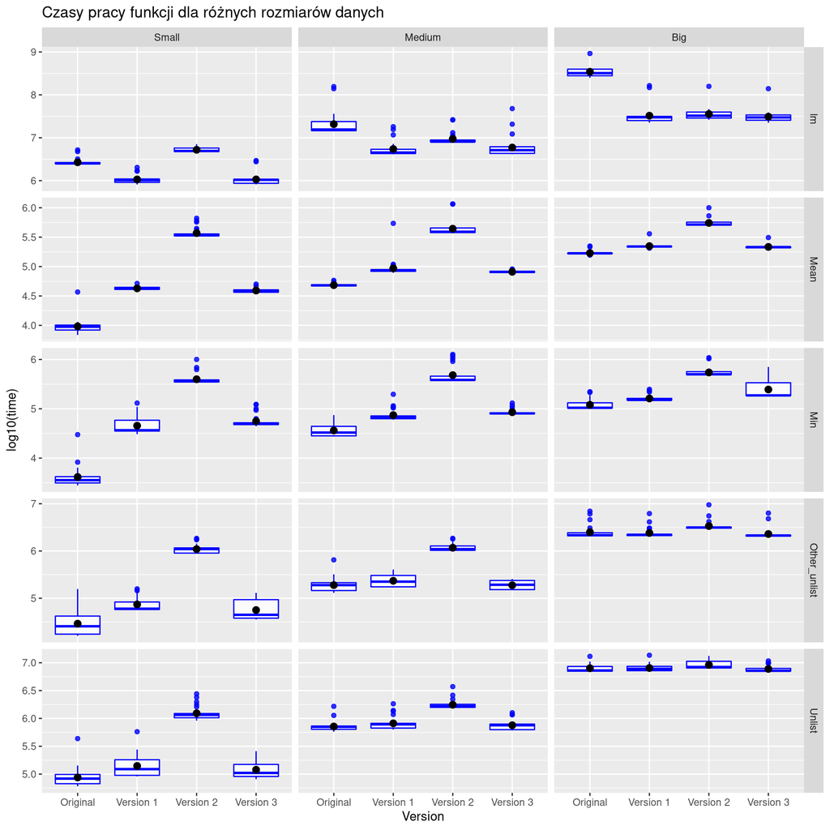

### Komentarz

Dość interesujące wnioski.

- W większości funkcji widzimy pewną prawdłowość. Ogółem rzecz ujmując, poza oryginałem najlepiej radzą sobie wyniki wersji pierwszej, zaraz za nimi wyniki wersji trzeciej, a wersja druga zostaje daleko w tyle. Prawdopodobnie jest to wina pętli `for()` oraz operacji wewnątrz niej.
- Przy dużych zbiorach danych różnica się zaciera - coraz więcej czasu zajmuje samo wywołanie funkcji oryginalnej w porównaniu z czasem potrzebnym do ewaluacji argumentów. Zwłaszcza różnica między wersjami pierwszą, trzecią i oryginałem staje się pomijalna.
- Wyjątkiem od reguły jest funkcja `lm()`, gdzie czas działania funkcji bazowej wyraźnie rośnie w zależności od rozmiaru danych. Dla dużych danych oryginał radzi sobie gorzej od funkcji w NSE.